# AllLife_Cust_Seg_0915

```python
# To enable plotting graphs in Jupyter notebook
%matplotlib inline
```

```python
# Numerical libraries
import numpy as np

from sklearn.model_selection import train_test_split

from sklearn.cluster import KMeans

# to handle data in form of rows and columns
import pandas as pd

# importing ploting libraries
import matplotlib.pyplot as plt

#importing seaborn for statistical plots
import seaborn as sns

from sklearn import metrics

import pandas as pd
```

```python
# reading the CSV file into pandas dataframe
mydata = pd.read_excel("Credit Card Customer Data.xlsx")
```

```python
mydata.head()
```

|  | Sl_No | Customer Key | Avg_Credit_Limit | Total_Credit_Cards | Total_visits_bank | Total_visits_online | Total_calls_made |
| --- | --- | --- | --- | --- | --- | --- | --- |
| 0 | 1 | 87073 | 100000 | 2 | 1 | 1 | 0 |
| 1 | 2 | 38414 | 50000 | 3 | 0 | 10 | 9 |
| 2 | 3 | 17341 | 50000 | 7 | 1 | 3 | 4 |
| 3 | 4 | 40496 | 30000 | 5 | 1 | 1 | 4 |
| 4 | 5 | 47437 | 100000 | 6 | 0 | 12 | 3 |

```python
# Lets drop Sl_No & Customer Keys because these will not make sence for analysis
mydata.drop(['Sl_No', 'Customer Key'], inplace=True,axis = 1)
print("Database has {} obserwations (customers) and {} columns (attributes).".format(mydata.shape[0],mydata.shape[1]))
print("Missing values in each column:\n{}".format(mydata.isnull().sum()))
print("Columns data types:\n{}".format(mydata.dtypes))
```

```
Database has 660 obserwations (customers) and 5 columns (attributes).
Missing values in each column:
Avg_Credit_Limit       0
Total_Credit_Cards     0
Total_visits_bank      0
Total_visits_online    0
Total_calls_made       0
dtype: int64
Columns data types:
Avg_Credit_Limit       int64
Total_Credit_Cards     int64
Total_visits_bank      int64
Total_visits_online    int64
Total_calls_made       int64
dtype: object
```

No attribute has missing values. All are Numeric numeric variables. Now, We will check how many, and what are the possible (unique) values in each categorical column.

```python
n_unique = mydata.nunique()
print("Number of unique values:\n{}".format(n_unique))
```

```
Number of unique values:
Avg_Credit_Limit       110
Total_Credit_Cards      10
Total_visits_bank        6
Total_visits_online     16
Total_calls_made        11
dtype: int64
```

```python
# Lets check distribution based on number credit cards because it seems critical attribute for segmentation
mydata['Total_Credit_Cards'].value_counts()
```

```
4     151
6     117
7     101
5      74
2      64
1      59
3      53
10     19
9      11
8      11
Name: Total_Credit_Cards, dtype: int64
```

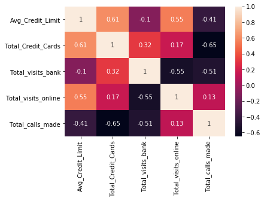

```python
# Lets check Corelation Matrix to know some attributes can be dropped or not
corr = mydata.corr()
sns.heatmap(corr, annot = True)
```

Avg_Credit_Limit is moderately corelated with Total_calls_made and Total_Credit_Cards, Lets check 5 pointer summary

```python
mydata.describe().transpose()
```

|  | count | mean | std | min | 25% | 50% | 75% | max |
| --- | --- | --- | --- | --- | --- | --- | --- | --- |
| Avg_Credit_Limit | 660.0 | 34574.242424 | 37625.487804 | 3000.0 | 10000.0 | 18000.0 | 48000.0 | 200000.0 |
| Total_Credit_Cards | 660.0 | 4.706061 | 2.167835 | 1.0 | 3.0 | 5.0 | 6.0 | 10.0 |
| Total_visits_bank | 660.0 | 2.403030 | 1.631813 | 0.0 | 1.0 | 2.0 | 4.0 | 5.0 |
| Total_visits_online | 660.0 | 2.606061 | 2.935724 | 0.0 | 1.0 | 2.0 | 4.0 | 15.0 |
| Total_calls_made | 660.0 | 3.583333 | 2.865317 | 0.0 | 1.0 | 3.0 | 5.0 | 10.0 |

# Obeservation Avg_Credit_Limit & Total_visits_online are highely right skewed Total_calls_made is moderately right skewed

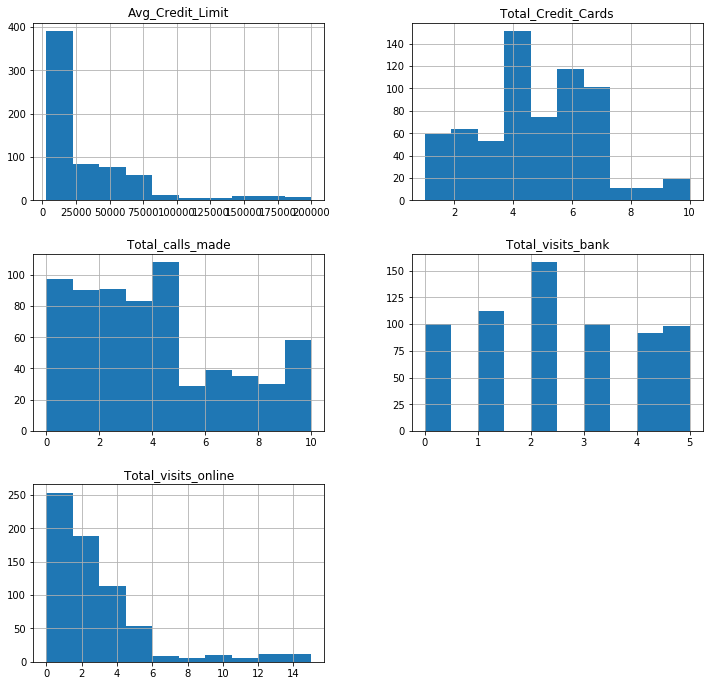

```python
# Let's us only plot the distributions of independent attributes
mydata.hist(figsize=(12,16),layout=(4,2));
```

# Obeservation Disributions of attributes Avg_Credit_Limit and Total_visits_online show high skewness Disribution of Total_calls_made attribute shows moderate skewness Distributions of Total_Credit_Cards are look normally distributed

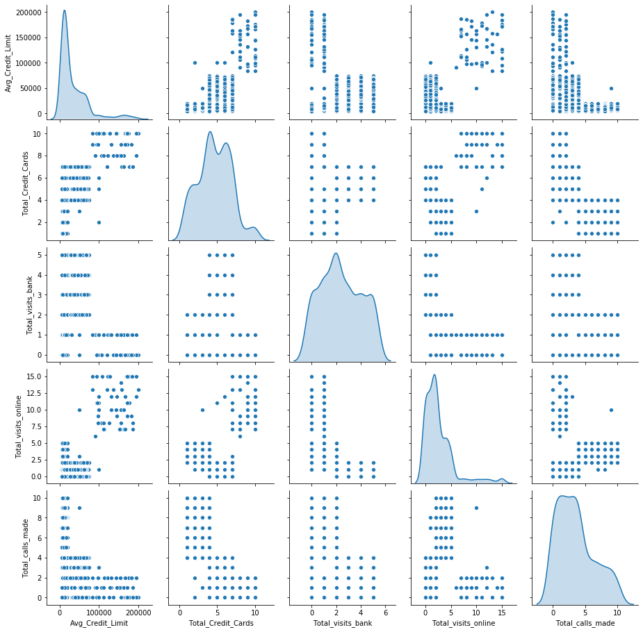

```python
# Lets check pairplot with KDE
import seaborn as sns
sns.pairplot(mydata, diag_kind='kde')
```

Based on the kde plots, we can work with 3 or 4 clusters because there are 2 -4 mutiple Gausian can be seen mixed here

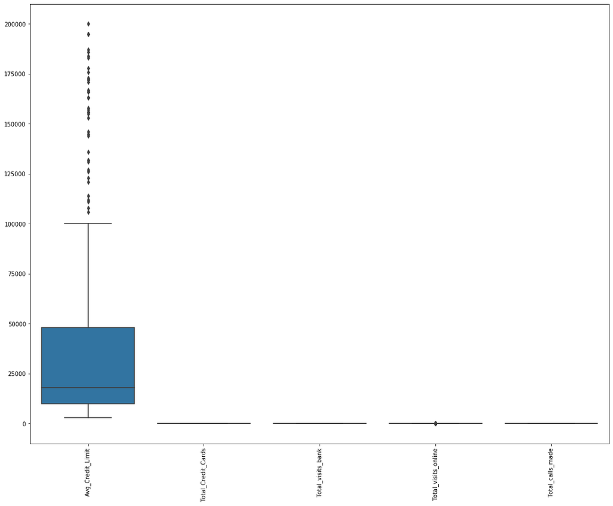

```python
# Let us check presence of outliers
plt.figure(figsize=(18,14))
box = sns.boxplot(data=mydata)
box.set_xticklabels(labels=box.get_xticklabels(),rotation=90);
```

Observations: One can see that, box-plots of attributes Avg_Credit_Limit and Total_visits_online attribute show outliers Box plot of Avg_Credit_Limit shows high amount of outliers

```python
# Since the dimensions of the data are not really known to us, it would be wise to standardize the data using z scores before we proceed

from scipy.stats import zscore

mydata_z = mydata.apply(zscore)
```

```python
mydata_z
```

|  | Avg_Credit_Limit | Total_Credit_Cards | Total_visits_bank | Total_visits_online | Total_calls_made |
| --- | --- | --- | --- | --- | --- |
| 0 | 1.740187 | -1.249225 | -0.860451 | -0.547490 | -1.251537 |
| 1 | 0.410293 | -0.787585 | -1.473731 | 2.520519 | 1.891859 |
| 2 | 0.410293 | 1.058973 | -0.860451 | 0.134290 | 0.145528 |
| 3 | -0.121665 | 0.135694 | -0.860451 | -0.547490 | 0.145528 |
| 4 | 1.740187 | 0.597334 | -1.473731 | 3.202298 | -0.203739 |
| ... | ... | ... | ... | ... | ... |
| 655 | 1.713589 | 2.443892 | -0.860451 | 2.520519 | -1.251537 |
| 656 | 1.314621 | 2.443892 | -0.860451 | 3.543188 | -0.553005 |
| 657 | 2.937092 | 1.520613 | -0.860451 | 2.179629 | -0.902271 |
| 658 | 3.655235 | 2.443892 | -0.860451 | 4.224968 | -1.251537 |
| 659 | 3.522245 | 1.982253 | -1.473731 | 3.202298 | -0.553005 |

660 rows × 5 columns

```python
#Finding optimal no. of clusters
from scipy.spatial.distance import cdist
from sklearn.metrics import silhouette_score
clusters=range(2,10)
meanDistortions=[]
sil=[]
for k in clusters:

    model=KMeans(n_clusters=k)
    model.fit(mydata_z)
    prediction=model.predict(mydata_z)
    #meanDistortions.append(sum(np.min(cdist(mydata_z, model.cluster_centers_, 'euclidean'), axis=1)) / mydata_z.shape[0])
    silhouette_avg = silhouette_score(mydata_z, prediction)

    sil.append(silhouette_avg)

    print (k,sil[-1])
```

```
2 0.41842496663215445
3 0.5157182558881063
4 0.3556670619372605
5 0.2717470361089752
6 0.2553480159463278
7 0.24821050966368377
8 0.22745995892855222
9 0.22799752605721058
```

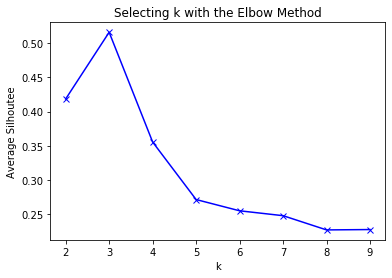

```python
#elbow plot to decide the number of segment
plt.plot(clusters, sil, 'bx-')
plt.xlabel('k')
plt.ylabel('Average Silhoutee')
plt.title('Selecting k with the Elbow Method')
```

```python
# Lets Set the value of k=3

kmeans = KMeans(n_clusters=3, n_init = 15, random_state=2345)
```

```python
kmeans.fit(mydata_z)
```

```
KMeans(n_clusters=3, n_init=15, random_state=2345)
```

```python
centroids = kmeans.cluster_centers_
```

```python
centroids
```

```
array([[-0.59579625, -1.05962278, -0.9015185 ,  0.32299678,  1.14810882],
       [-0.02106178,  0.37368962,  0.6663945 , -0.55367163, -0.55300488],
       [ 2.83176409,  1.86222621, -1.10576269,  2.82731942, -0.87432983]])
```

```python
#Clculate the centroids for the columns
centroid_df = pd.DataFrame(centroids, columns = list(mydata_z) )
```

```python
print(centroid_df)
```

```
   Avg_Credit_Limit  Total_Credit_Cards  Total_visits_bank  \
0         -0.595796           -1.059623          -0.901518
1         -0.021062            0.373690           0.666395
2          2.831764            1.862226          -1.105763

   Total_visits_online  Total_calls_made
0             0.322997          1.148109
1            -0.553672         -0.553005
2             2.827319         -0.874330
```

```python
## creating a new dataframe only for labels and converting it into categorical variable
df_labels = pd.DataFrame(kmeans.labels_ , columns = list(['labels']))

df_labels['labels'] = df_labels['labels'].astype('category')
```

```python
# Joining the label dataframe with the data frame.
df_labeled = mydata.join(df_labels)
```

```python
df_analysis = (df_labeled.groupby(['labels'] , axis=0)).head(4177)  # the groupby creates a groupeddataframe that needs
# to be converted back to dataframe.
df_analysis
```

[output not shown]

660 rows × 7 columns

```python
# Lets check the distrubution based on segment
df_labeled['labels'].value_counts()
```

```
1    386
0    224
2     50
Name: labels, dtype: int64
```

```python
#sns.pairplot(df_labeled,hue="labels")
```

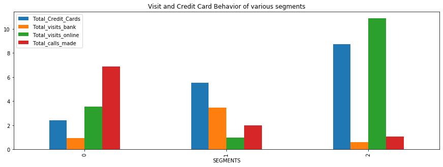

```python
(df_labeled[[ 'Total_Credit_Cards','Total_visits_bank', 'Total_visits_online', 'Total_calls_made', 'labels']]
 .groupby('labels').mean().plot.bar(figsize=(15, 5)))
plt.title('Visit and Credit Card Behavior of various segments')
plt.xlabel('SEGMENTS');
```

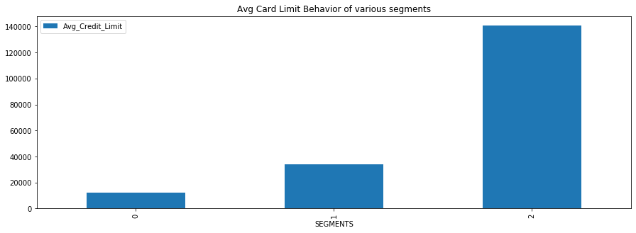

```python
(df_labeled[[ 'Avg_Credit_Limit', 'labels']]
 .groupby('labels').mean().plot.bar(figsize=(15, 5)))
plt.title('Avg Card Limit Behavior of various segments')
plt.xlabel('SEGMENTS');
```

[output not shown]

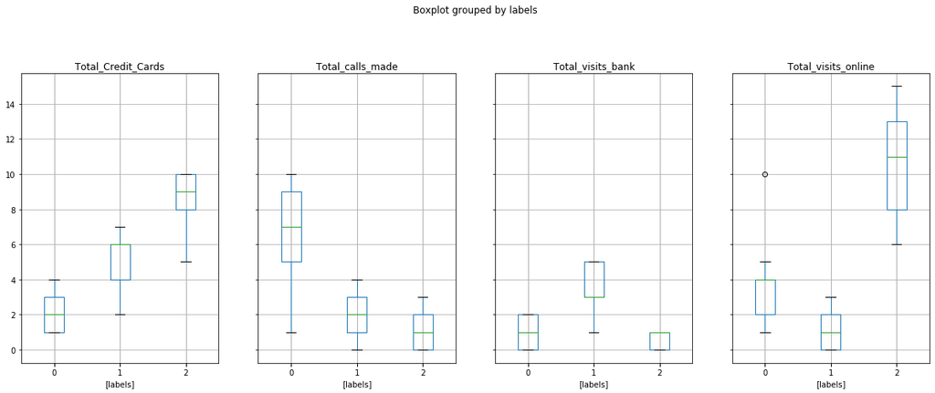

```python
df_labeled[[ 'Total_Credit_Cards','Total_visits_bank', 'Total_visits_online', 'Total_calls_made', 'labels']].boxplot(by = 'labels',  layout=(2,4), figsize=(20, 15))
```

```
array([[<matplotlib.axes._subplots.AxesSubplot object at 0x000000000EB19788>,
      dtype=object)
```

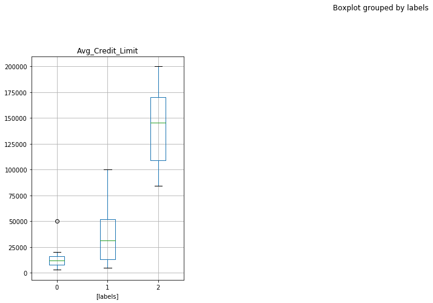

```python
df_labeled[['Avg_Credit_Limit', 'labels']].boxplot(by = 'labels',  layout=(2,4), figsize=(20, 15))
```

Seeing above boxplot and barplot, we found that there enough pattern to justify three clusters using K-Mean clustering

```python
# checking cophenet to decide which link can be useful for heirarchical clustering
from scipy.cluster.hierarchy import dendrogram, linkage,cophenet
from scipy.spatial.distance import pdist
#cc,cophn_dist=cophenet(Z,pdist(mydata_z))
links=['single','complete','average','ward','median']
for each in links:
    print (each)
    Z = linkage(mydata_z, method=each, metric='euclidean')
    cc,cophn_dist=cophenet(Z,pdist(mydata_z))
    print (each,cc)
```

```
single
single 0.7391220243806552
complete
complete 0.8599730607972423
average
average 0.8977080867389372
ward
ward 0.7415156284827493
median
median 0.8893799537016724
```

Find out the linkage matrix

```python
#Use ward as linkage metric and distance as Eucledian
links=['single','complete','average','ward','median']
```

```python
#### generate the linkage matrix using average link as it has values close to 1 which is best.
from scipy.cluster.hierarchy import dendrogram, linkage
Z = linkage(mydata_z, 'average', metric='euclidean')
Z.shape
```

```
(659, 4)
```

```python
Z[:]
```

```
array([[ 464.        ,  497.        ,    0.        ,    2.        ],
       [ 250.        ,  361.        ,    0.        ,    2.        ],
       [ 252.        ,  324.        ,    0.        ,    2.        ],
       ...,
       [   0.        , 1309.        ,    3.11135778,  387.        ],
       [1315.        , 1316.        ,    3.25253923,  610.        ],
       [1314.        , 1317.        ,    5.45418035,  660.        ]])
```

Plot the dendrogram for the consolidated dataframe

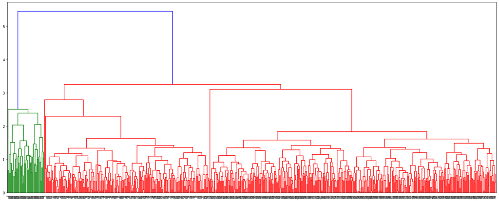

```python
plt.figure(figsize=(25, 10))
dendrogram(Z)
plt.show()
```

Recreate the dendrogram for last 12 merged clusters From the truncated dendrogram, find out the optimal distance between clusters which u want to use an input for clustering data

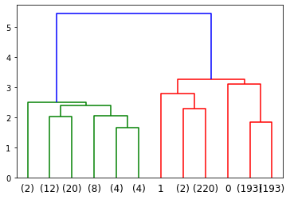

```python
# Hint: Use truncate_mode='lastp' attribute in dendrogram function to arrive at dendrogram
dendrogram(
    Z,
    truncate_mode='lastp',  # show only the last p merged clusters
    p=12,  # show only the last p merged clusters
)
plt.show()
```

```python
#Use this distance measure(max_d) and fcluster function to cluster the data into 3 different groups
max_d = 3.2
```

```python
from scipy.cluster.hierarchy import fcluster
clusters = fcluster(Z, max_d, criterion='distance')
set(clusters)
```

```
{1, 2, 3}
```

```python
# Lets add this hierarchical segment number in original dataframe
mydata['cluster_label']=clusters
```

```python
# Lets check data distribution based on hierarchical clusters
mydata.groupby(['cluster_label']).size()
```

```
cluster_label
1     50
2    223
3    387
dtype: int64
```

```python
# Calculate Avg Silhoutte Score

from sklearn.metrics import silhouette_score
silhouette_score(mydata_z,clusters)
```

```
0.515922432650965
```

Silhouette Score is better when closer 1 and worse when closer to -1 here, it is 0.51 which is good. Final dendogram with 'Average linkage'

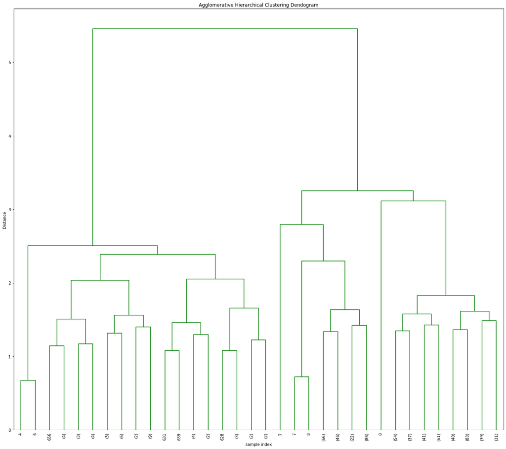

```python
from scipy.cluster.hierarchy import dendrogram, linkage
from scipy.spatial.distance import pdist
import matplotlib.pyplot as plt
plt.figure(figsize=(18, 16))
plt.title('Agglomerative Hierarchical Clustering Dendogram')
plt.xlabel('sample index')
plt.ylabel('Distance')
Z = linkage(mydata_z, 'average')
dendrogram(Z,leaf_rotation=90.0,p=5,color_threshold=52,leaf_font_size=10,truncate_mode='level')
plt.tight_layout()
```

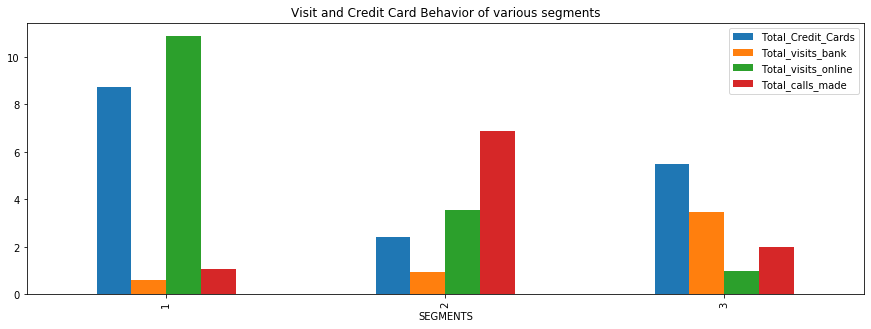

```python
(mydata[[ 'Total_Credit_Cards','Total_visits_bank', 'Total_visits_online', 'Total_calls_made', 'cluster_label']]
 .groupby('cluster_label').mean().plot.bar(figsize=(15, 5)))
plt.title('Visit and Credit Card Behavior of various segments')
plt.xlabel('SEGMENTS');
```

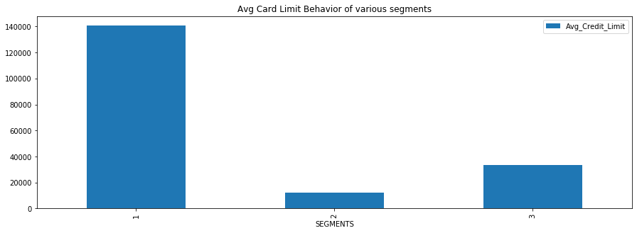

```python
(mydata[[ 'Avg_Credit_Limit', 'cluster_label']]
 .groupby('cluster_label').mean().plot.bar(figsize=(15, 5)))
plt.title('Avg Card Limit Behavior of various segments')
plt.xlabel('SEGMENTS');
```

[output not shown]

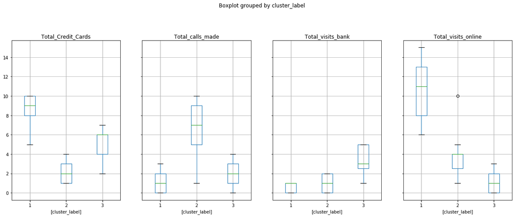

```python
mydata[[ 'Total_Credit_Cards','Total_visits_bank', 'Total_visits_online', 'Total_calls_made', 'cluster_label']].boxplot(by = 'cluster_label',  layout=(2,4), figsize=(20, 15))
```

```
array([[<matplotlib.axes._subplots.AxesSubplot object at 0x00000000170BCB48>,
      dtype=object)
```

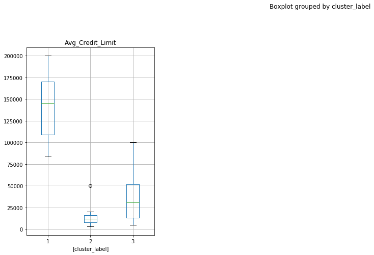

```python
mydata[['Avg_Credit_Limit', 'cluster_label']].boxplot(by = 'cluster_label',  layout=(2,4), figsize=(20, 15))
```

Seeing above boxplot and barplot, we found that there enough pattern to justify three clusters using Hierarchical clusteringAverage silhouette score for both methods: 1) K-Mean -> As calculated in cell # 18, the average silhouette score is 0.5157182558881063 2) Hierarchical -> As calculated in cell # 148, the average silhouette score is 0.515922432650965Compare K-means clusters with Hierarchical clusters 1) Hierarchical Clustring with three cluster, we found below distribution 1 50 2 223 3 387 2)K-Mean Clustring with three cluster, we found below distribution 1 386 0 224 2 50 If we compare both K-Mean & Hierarchical clustering, we can conclude that both are providing similar result because average silhouette score and distribution per segment are matching. Conclusion -> 1. How many different segments of customers are there? Ans: We found on high level, there are three different segments are there. 2. How are these segments different from each other? Ans: These three segments are different from each other based one below attributes: a) Total number of credit cards a customer is having b) different channels through which customer has contacted the bank for any queries, different channels include online and through a call centre. 3. What are your recommendations to the bank on how to better market to and service these customers? Ans: The person having 1-2 credit cards are visiting more through call center than online so call center should provide qauality service to this segment. The person having 4-5 credit cards are visiting more personally than online or call center so personal banker at branch can better help to this segment by explaining then the other new offers and about digital services so that customer can save their time. The person having 6 or more credit cards are visiting mostly using online so above TWO segment's customer(who has less than 6 cards) can also be inspired to use this online digital channel for bertter expirience nand services.